# Value Perception in Engaging Conversational Speech

Analysis Presentation 1

2024-07-07

# Exploratory Data Analysis

First, it may be important to visually inspect the distribution of the data. The figure below suggests that the data is not precisely normally distributed because it is bounded at 0, especially for the boring speaking context. This is expected, as people cannot decide to spend less than 0 seconds in a social interaction. LMMs can be quite robust to violations of normality, especially with larger sample sizes. Therefore, even if the residuals are not perfectly normal, the model might still provide valid inference. However, this motivates checking the distribution of the residuals after fitting the LMM to make sure it is normal. If it is not, the data might require a simple transformation (e.g., log or squared root) or that a different framework is used (e.g., GLMM).

Time-bidding data distributions across speaking and semantic contexts.

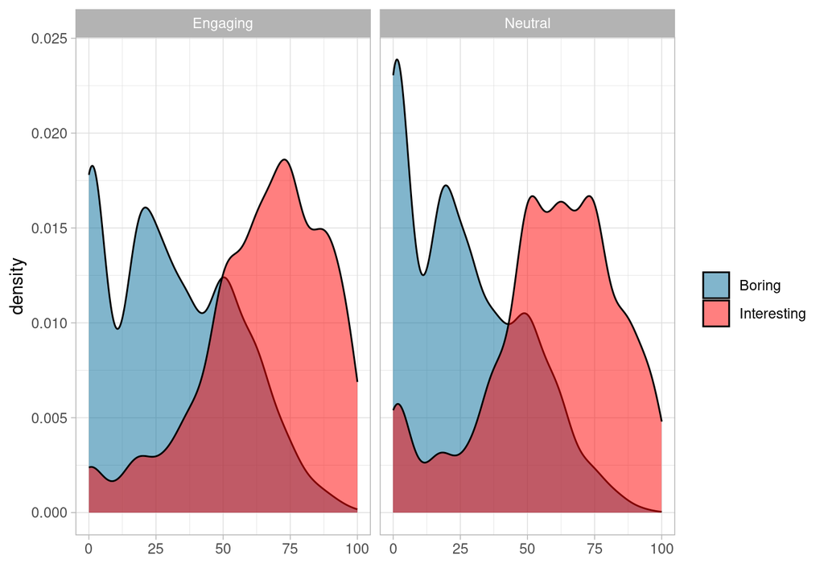

The following figure shows that there is considerable variability between between different listeners’ time bids across semantic and speaking contexts, as well as between different speakers’ elicited time bids under the various conditions. This is expected and justifies the inclusion of both by-speaker and by-listener random effects in subsequent statistical models.

By-speaker and by-listener comparison of mean time-bidding scores for different content and prosody types. In (A) each line represent a single speaker, while in (B) each line represents a single listener, depicting the change in mean scores between the two prosody types.

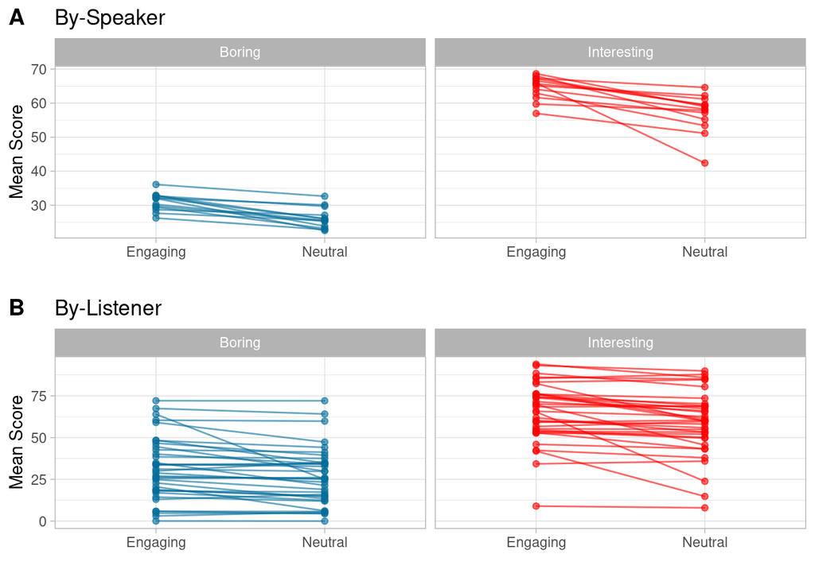

Next, we will explore the social trait ratings of trustworthiness, friendliness, dominance, competence, and attractiveness. The figure below, displaying by-speaker mean scores and their standard deviations, shows that all ratings were higher in the engaging than in the neutral speaking context. The figure in the right-side margin displays the means collapsed across speakers with their 95% confidence intervals (CIs). The narrow CIs suggest that the ratings were robust across listeners.

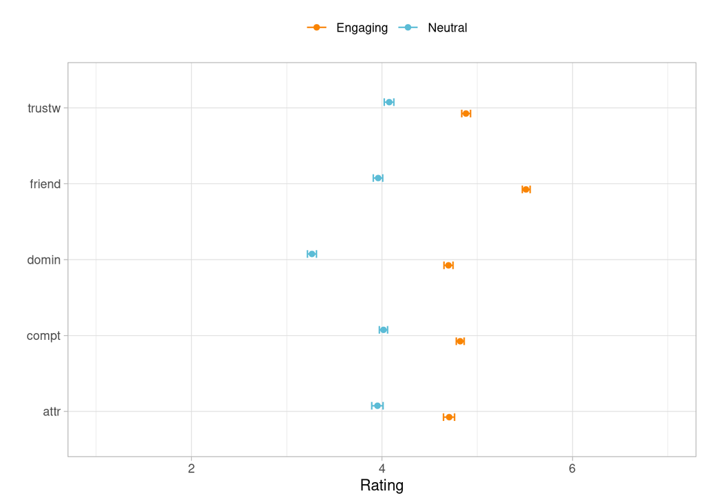

(Right:) Ratings of social trait perception collapsed across speakers. Points are mean scores and error bars represent the 95% CIs.

(Left:) By-speaker ratings of social traits. Points are mean scores and error bars represent the standard deviation.

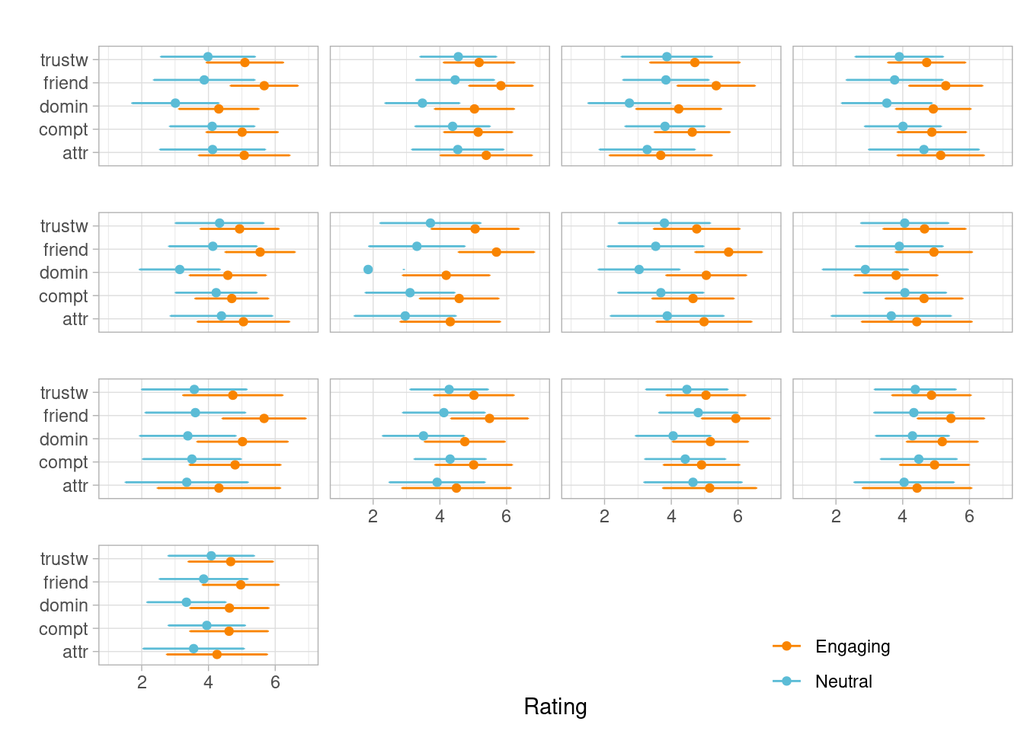

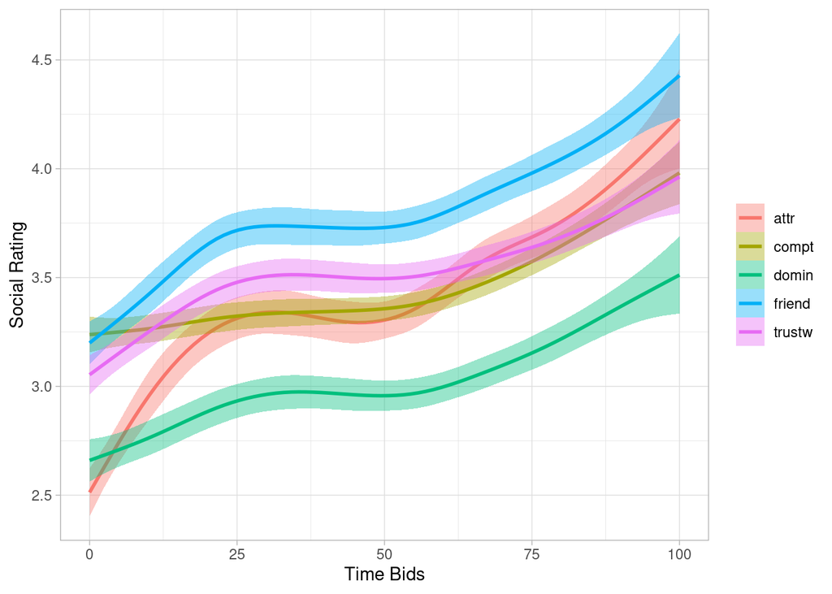

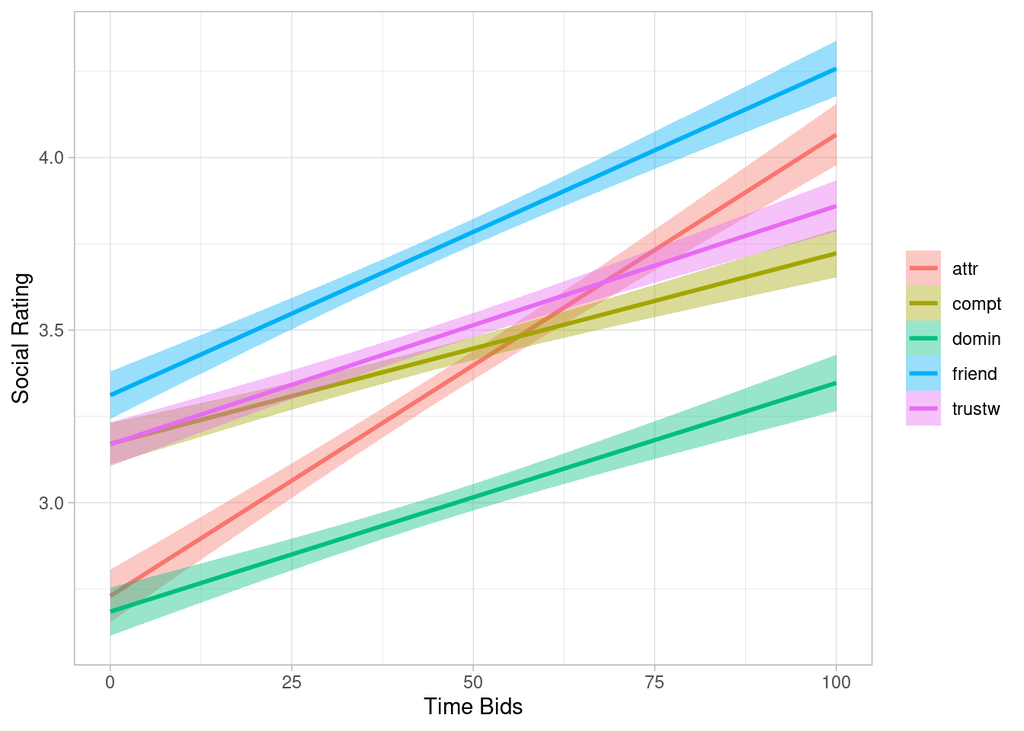

The experiment design was based on the assumption of the Stereotype-Content Model and the BIAS Map (Cuddy et al., 2008). This framework poses that when people form interpersonal impressions of others, they use two main dimensions to evaluate them: warmth and competence. The former is an evaluation of the stranger’s intent to help or harm; the former evaluates their ability to act upon it (Cuddy et al., 2008; Fiske et al., 2007). Studies investigating the formation of first impressions for the voice have found evidence supporting this notion, although they have labeled the dimensions of this vocal evaluative space a little differently, e.g., likability and dominance, or trusworthiness and competence (Baus et al., 2019; McAleer et al., 2014).

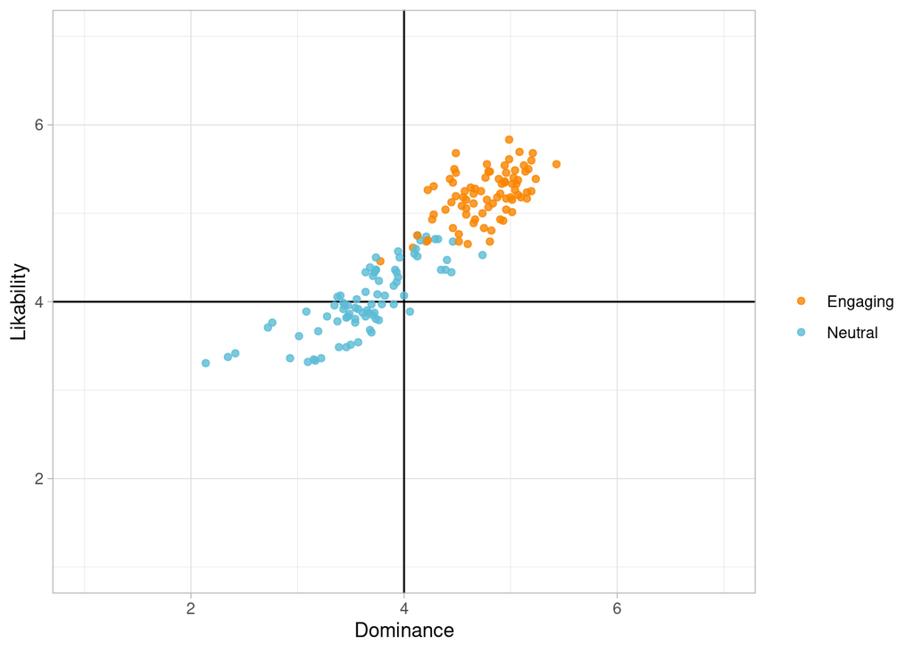

(Right:) Scatter plot of Dominance by Likability with the data points colored by speaking context. Each data point is one speech sample averaged across listener ratings.

(Left:) Scatter plot of Dominance by Likability with the data points hue indicating the mean time-bid score for that utterance. Each data point is one speech sample averaged across listener ratings.

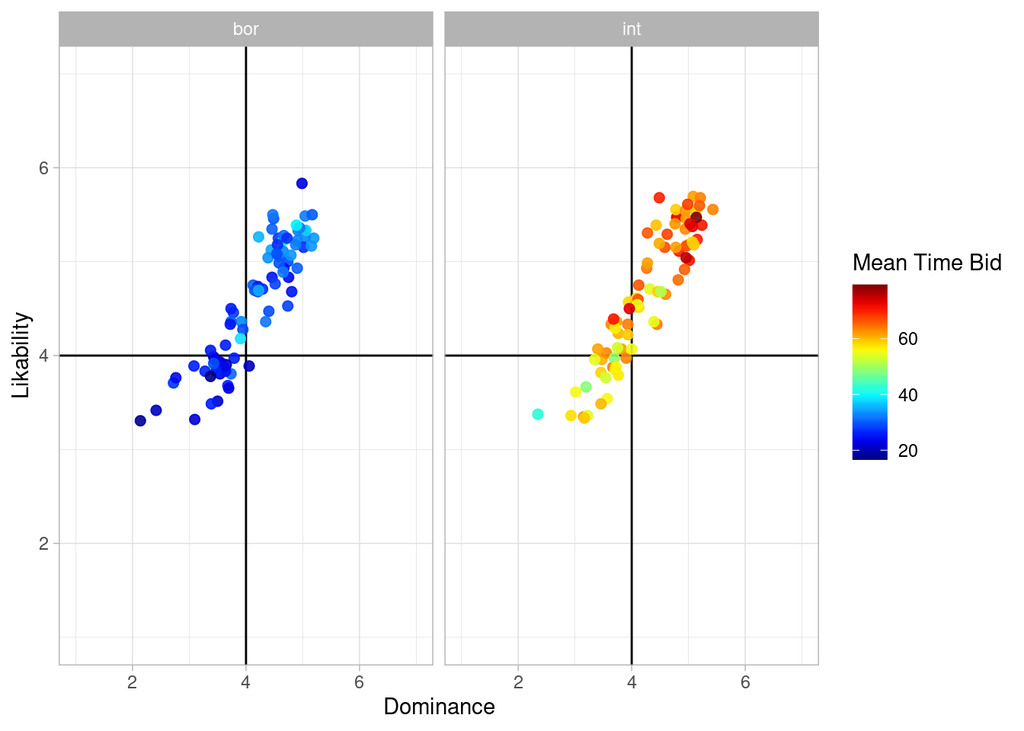

## Exploratory Principal Component Analysis (PCA)

The data thus far suggests several of my variables are quite correlated. This can be more clearly seen in the correlation plot below:

Correlation plot including all social traits and time bids.

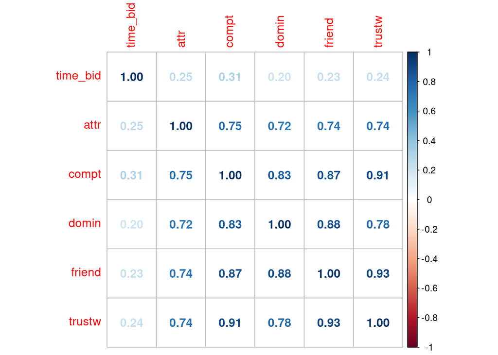

Indeed, the social trait ratings are very correlated with each other, but time bids has only a small-to-moderate correlation with all the social trait ratings. These correlations among the social traits, as we gather from previous plots, may be manly driven by the speaking context. That is, because change from one speaking context to another (neutral to engaging) leads to higher ratings across all social traits. We want to avoid collinearity issues in the statistical analysis, so it is important to avoid including independent variables that have a strong correlation between themselves. A PCA might more clearly reveal the correlations between the variables to make an informed decision. I have added the interest scores obtained during the validation of the written stimuli by an independent sample to make the relationship between time bids and semantic context more explicit.

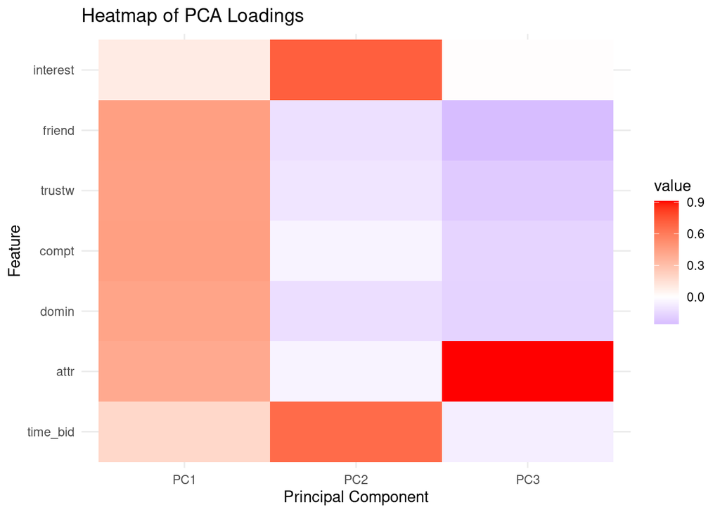

(Right:) Principal component loadings.

(Left:) PCA of all continuos variables obtained in the main task. Each data point represents one speech sample and they are colored by speaking and semantic context. red = boring engaing; green = boring neutral; blue = interesting engaging; purple = interesting neutral.

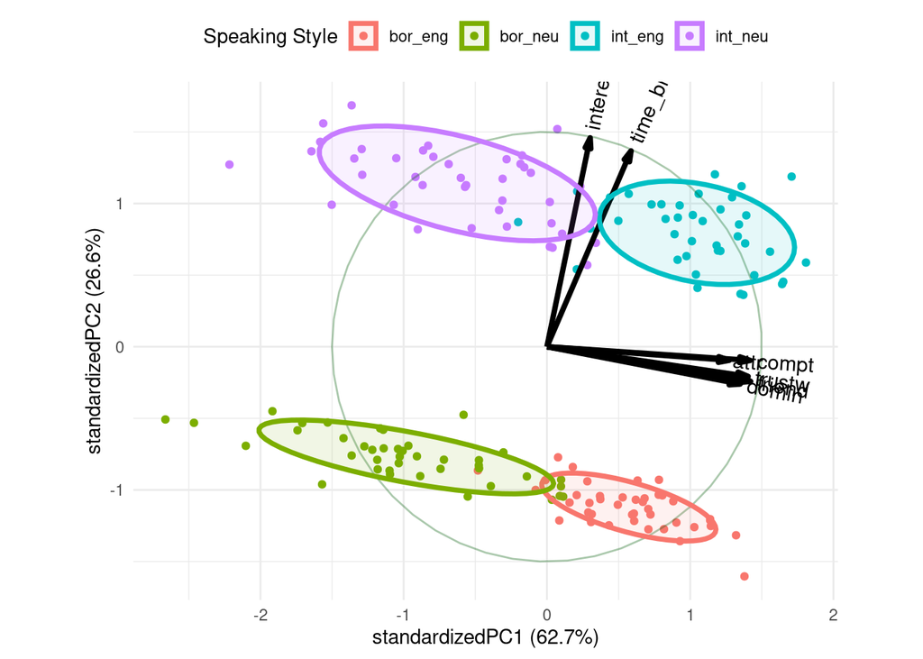

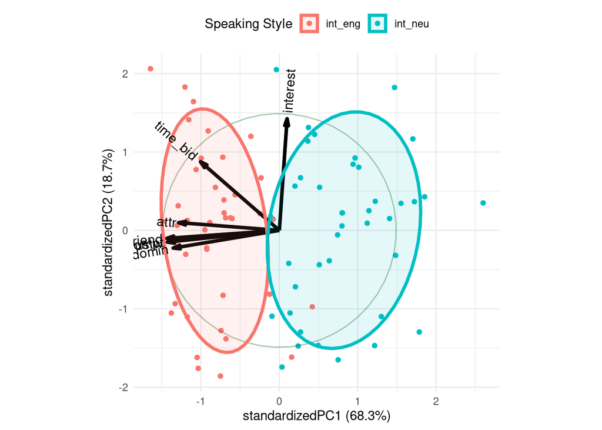

PCA for interesting stimuli

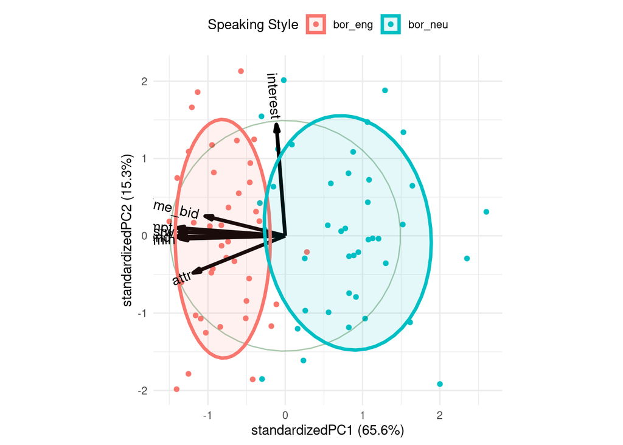

PCA for boring stimuli

The PCA reveals two clear principal components. PC1 has high loadings for all social traits and clearly distinguishes between neutral and engaging speaking contexts. PC2 has a high loading of interest scores and time bids. Visual inspection suggests that value perception (as indexed by time bids) is mainly driven by the linguistic contents of the speech signal. The prosody and speaker characteristics display a small modulatory effect. In other words, it could be that people prefer to spend time in an interesting conversation regardless of the speaker’s characteristics – although the way the speaker talks might enhance or reduce this preference a little. This should be confirmed with a significance test.

The plots in the right-side margin show the same PCA visualization but applied only to the subset corresponding to each semantic context (interesting and boring). It suggest that the relationship between time bids and each of PC1 and PC2 changes across semantic contexts.

However, the main take away from this exploratory analysis is that the social traits are strongly correlated among themselves and with the speaking context, suggesting I should use either a summary of the social traits (e.g., a PC) or the speaking context as independent variable capturing this dimension of variability in my data. The latter is my preference for being less redundant and more suitable for my main hypothesis (which is regarding speaking contexts, not social impressions).

# Statistical Modeling

Model Summary

|  | Time Bids |  |  |  |
| --- | --- | --- | --- | --- |
| Predictors | Estimates | std. Error | CI | p |
| (Intercept) | 44.864 | 2.684 | 39.602 – 50.125 | **<0.001** |
| semanticContext1 | 16.350 | 1.493 | 13.422 – 19.277 | **<0.001** |
| speakingContext1 | -2.946 | 0.822 | -4.558 – -1.334 | **<0.001** |
| spkr gender1 | -0.268 | 0.648 | -1.538 – 1.002 | 0.679 |
| semanticContext1 × speakingContext1 | -0.573 | 0.201 | -0.967 – -0.179 | **0.004** |
| semanticContext1 × spkr gender1 | -0.877 | 0.465 | -1.788 – 0.033 | 0.059 |
| speakingContext1 × spkr gender1 | -0.029 | 0.475 | -0.961 – 0.902 | 0.951 |
| semanticContext1 × speakingContext1 × spkr gender1 | 0.139 | 0.201 | -0.255 – 0.533 | 0.489 |
| Random Effects |  |  |  |  |
| σ<sup>2</sup> | 207.60 |  |  |  |
| τ<sub>00</sub> <sub>stimulus</sub> | 13.86 |  |  |  |
| τ<sub>00</sub> <sub>subject</sub> | 244.18 |  |  |  |
| τ<sub>00</sub> <sub>speaker</sub> | 2.67 |  |  |  |
| τ<sub>11</sub> <sub>stimulus.speakingContext1</sub> | 0.19 |  |  |  |
| τ<sub>11</sub> <sub>subject.semanticContext1</sub> | 72.51 |  |  |  |
| τ<sub>11</sub> <sub>subject.speakingContext1</sub> | 16.20 |  |  |  |
| τ<sub>11</sub> <sub>speaker.speakingContext1</sub> | 2.41 |  |  |  |
| ρ<sub>01</sub> <sub>stimulus</sub> | -0.33 |  |  |  |
| ρ<sub>01</sub> <sub>subject.semanticContext1</sub> | 0.02 |  |  |  |
| ρ<sub>01</sub> <sub>subject.speakingContext1</sub> | -0.02 |  |  |  |
| ρ<sub>01</sub> <sub>speaker</sub> | 0.47 |  |  |  |
| ICC | 0.63 |  |  |  |
| N <sub>subject</sub> | 36 |  |  |  |
| N <sub>speaker</sub> | 13 |  |  |  |
| N <sub>stimulus</sub> | 81 |  |  |  |
| Observations | 5832 |  |  |  |
| Marginal R<sup>2</sup> / Conditional R<sup>2</sup> | 0.334 / 0.753 |  |  |  |